# Impacto del estilo de vida de los universitarios en su autorregulación del estrés

Diciembre 17, 2021

# 1. Introducción

## 1.1. Importancia y justificación

Dado el contexto actual, los estudiantes universitarios han presentado cuadros de estrés que, se ve influenciado en su estilo de vida. Por tal motivo, la importancia del presente trabajo radica en conocer la necesidad de dar a conocer dichas variables que, junto con un profundo análisis estadístico, podremos reconocer las tendencias presentes en el tema. Ello sería beneficioso, ya que, al identificarlas se podrían poner en práctica, es decir, qué hacer y qué no, de manera que podría mejorar el bienestar de los estudiantes.

## 1.2. Diagrama de Gant

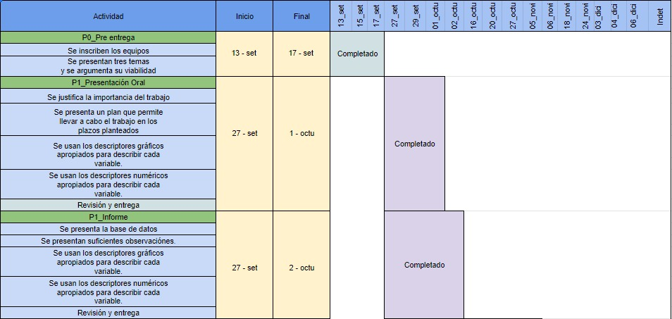

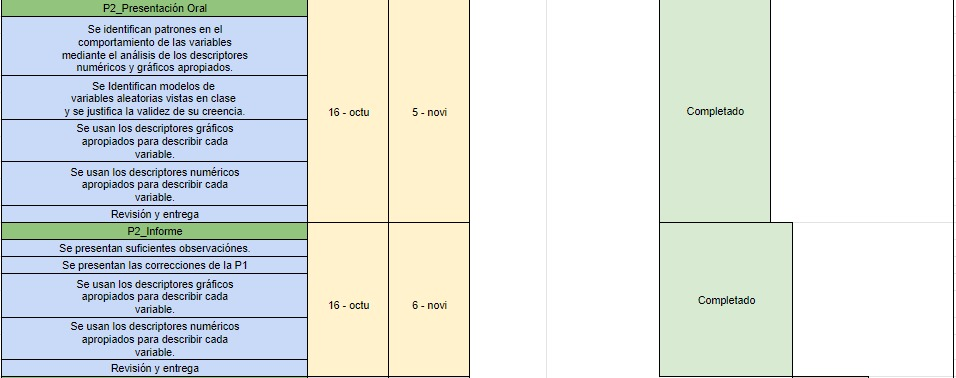

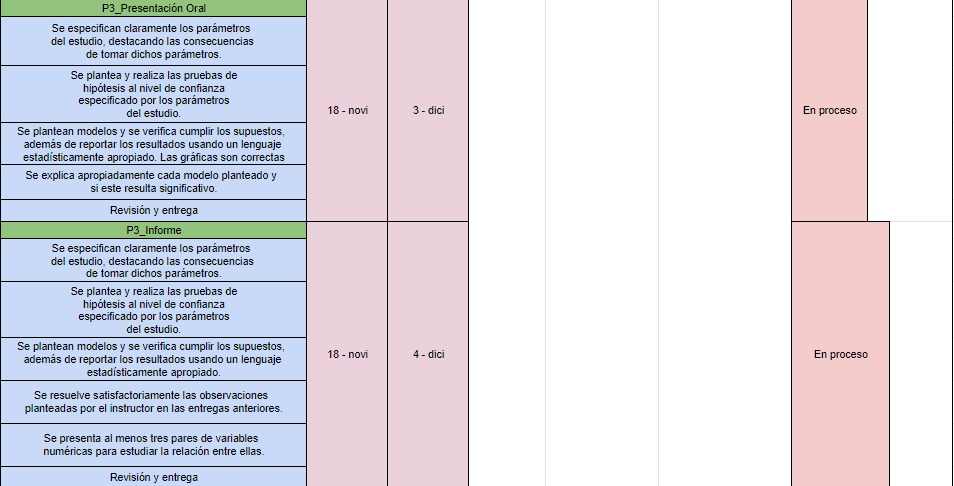

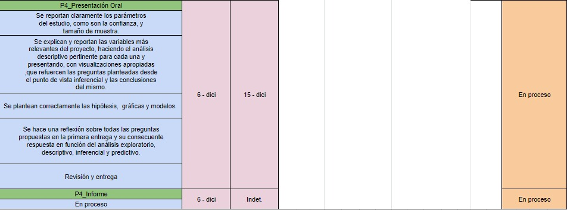

# 2. Objetivos

**General**

- Se busca responder la pregunta planteada de las previas presentaciones “¿Existe una relación entre el estilo de vida de las personas y su autorregulación del estrés?”
- Mostrar el resultado final del avance y correciones respectivas a las anteriores presentaciones.

# 3. Recepción y limpieza de data

```r
library(readr)
library(dplyr)

# Leer archivo .csv
DataBase <- read_csv("DB.csv")

# Renombramiento de variables
DataBase %>% rename(MarcaTemporal = `Marca temporal`, Genero = Género, Universidad = `¿A qué Universidad perteneces?`, Ciclo = `Ciclo relativo`, HorasDiariasDeSueno = `¿Cúantas horas duermes al día (aproximadamente)?`, HorasSemanalesDeEjercicio = `¿Cuántas horas te dedicas a realizar actividades físicas a la semana (aproximadamente)?`, Meditacion = `¿Meditas?`, ComidasDiarias = `¿Cuántas comidas consumes al día?`, FrecuenciaComidaChatarra = `¿Con qué frecuencia consumes comida chatarra?`, FrecuenciaAireLibre = `¿Con qué frecuencia pasas tiempo al aire libre (amigos, familia, solo)?`, HorasDiariasDeOcio = `Horas de ocio en dispositivos electrónicos diarias (videojuegos, redes sociales, plataformas de streaming, etc)`, Sintoma1 = `¿Cuántos de los siguientes síntomas ha presentado recientemente? [Dolores de cabeza]`, Sintoma2 = `¿Cuántos de los siguientes síntomas ha presentado recientemente? [Tensión muscular en cuello y espalda]`, Sintoma3 = `¿Cuántos de los siguientes síntomas ha presentado recientemente? [Fatiga]`, Sintoma4 = `¿Cuántos de los siguientes síntomas ha presentado recientemente? [Ansiedad, preocupación, fobias]`, Sintoma5 = `¿Cuántos de los siguientes síntomas ha presentado recientemente? [Dificultad para conciliar el sueño]`, Sintoma6 = `¿Cuántos de los siguientes síntomas ha presentado recientemente? [Irritabilidad]`, Sintoma7 = `¿Cuántos de los siguientes síntomas ha presentado recientemente? [Arranques de enojo/hostilidad]`, Sintoma8 = `¿Cuántos de los siguientes síntomas ha presentado recientemente? [Aburrimiento, depresión]`, Sintoma10 =`¿Cuántos de los siguientes síntomas ha presentado recientemente? [Comer demasiado o demasiado poco]`, Sintoma11 = `¿Cuántos de los siguientes síntomas ha presentado recientemente? [Diarrea, calambres, gases, constipación]`, Sintoma12 = `¿Cuántos de los siguientes síntomas ha presentado recientemente? [Inquietud, picazón, tics]`, EscalaMotivacion = `Del 1 al 5, ¿qué tan motivado te encuentras actualmente respecto a tus proyectos personales?`, EscalaEstres = `Del 1 al 5, ¿qué tan estresado te sientes últimamente?`) -> DataBase1
```

```r
DataBase1 <- DataBase1 %>% slice(-c(16))
DataBase1 <- DataBase1 %>% slice(-c(106))
DataBase1 <- DataBase1 %>% slice(-c(120))
DataBase1 <- DataBase1 %>% slice(-c(125))
toupper(DataBase1$Universidad) -> DataBase1$Universidad
DataBase1$Universidad[DataBase1$Universidad == "UDEP"] <- "UNIVERSIDAD DE PIURA."
DataBase1$Universidad[DataBase1$Universidad == "ULIMA"] <- "UNIVERSIDAD DE LIMA."
DataBase1$Universidad[DataBase1$Universidad == "UCSUR"] <- "UNIVERSIDAD CIENTIFICA DEL SUR."
DataBase1$Universidad[DataBase1$Universidad == "UNI" | DataBase1$Universidad == "UNIVERSIDAD NACIONAL DE INGENIERÍA." | DataBase1$Universidad == "UNIVERSIDAD NACIONAL DE INGENIERIA" | DataBase1$Universidad == "UNIVERSIDAD NACIONAL DE INGENERIA"] <- "UNIVERSIDAD NACIONAL DE INGENIERIA."
DataBase1$Universidad[DataBase1$Universidad == "UDEP"] <- "UNIVERSIDAD DE PIUR.A"
DataBase1$Universidad[DataBase1$Universidad == "UPC" | DataBase1$Universidad == "UNIVERSIDAD PERUANA DE CIENCIAS APLICADAS (UPC)" | DataBase1$Universidad == "UPC - UNIVERSIDAD PERUANA DE CIENCIAS APLICADAS."] <- "UNIVERSIDAD PERUANA DE CIENCIAS APLICADAS."
DataBase1$Universidad[DataBase1$Universidad == "UNIVERSIDAD DE INGENIERÍA Y TECNOLOGÍA." | DataBase1$Universidad == "UNIVERSIDAD DE INGENIERíA  Y TECNOLOGíA." | DataBase1$Universidad == "UNIVERSIDAD DE INGENIERÍA Y TECNOLOGÍA."] <- "UTEC"
DataBase1$Universidad[DataBase1$Universidad == "CÉSAR VALLEJO." | DataBase1$Universidad == "UCV"] <- "UNIVERSIDAD CESAR VALLEJO."
DataBase1$Universidad[DataBase1$Universidad == "UARM"] <- "UNIVERSIDAD ANTONIO RUIZ DE MONTOYA."
DataBase1$Universidad[DataBase1$Universidad == "PONTIFICA UNIVERSIDAD CATÓLICA DEL PERÚ."] <- "PUCP"
DataBase1$Universidad[DataBase1$Universidad == "UNIVERSIDAD AUTÓNOMA DE PERÚ"] <- "UNIVERSIDAD AUTONOMA."
DataBase1$Universidad[DataBase1$Universidad == "UPN"] <- "UNIVERSIDAD PRIVADA DEL NORTE."

# Cambiar tipos de datos
DataBase1$EscalaEstres <- as.character(DataBase1$EscalaEstres)
DataBase1$EscalaMotivacion <- as.character(DataBase1$EscalaMotivacion)
DataBase1$HorasDiariasDeSueno <- as.numeric(DataBase1$HorasDiariasDeSueno)
DataBase1$ComidasDiarias <- as.numeric(DataBase1$ComidasDiarias)

# Pasar los sintomas a valores a numericos
v1 <- c("Nunca", "Una vez al mes", "Una vez a la semana", "2-3 veces por semana", "Cada noche o día", "Uno o dos veces al día", "Casi todo el día, todos los días")
v2 <- c("0", "1", "2", "3", "4", "5", "6")
cont <- 1
while(cont <= length(v1)){
  DataBase1$Sintoma1[DataBase1$Sintoma1 == v1[cont]] <- v2[cont]
  DataBase1$Sintoma2[DataBase1$Sintoma2 == v1[cont]] <- v2[cont]
  DataBase1$Sintoma3[DataBase1$Sintoma3 == v1[cont]] <- v2[cont]
  DataBase1$Sintoma4[DataBase1$Sintoma4 == v1[cont]] <- v2[cont]
  DataBase1$Sintoma5[DataBase1$Sintoma5 == v1[cont]] <- v2[cont]
  DataBase1$Sintoma6[DataBase1$Sintoma6 == v1[cont]] <- v2[cont]
  DataBase1$Sintoma7[DataBase1$Sintoma7 == v1[cont]] <- v2[cont]
  DataBase1$Sintoma8[DataBase1$Sintoma8 == v1[cont]] <- v2[cont]
  DataBase1$Sintoma10[DataBase1$Sintoma10 == v1[cont]] <- v2[cont]
  DataBase1$Sintoma11[DataBase1$Sintoma11 == v1[cont]] <- v2[cont]
  DataBase1$Sintoma12[DataBase1$Sintoma12 == v1[cont]] <- v2[cont]
  cont <- cont + 1
}
DataBase1$Sintoma1 <- as.numeric(DataBase1$Sintoma1)
DataBase1$Sintoma2 <- as.numeric(DataBase1$Sintoma2)
DataBase1$Sintoma3 <- as.numeric(DataBase1$Sintoma3)
DataBase1$Sintoma4 <- as.numeric(DataBase1$Sintoma4)
DataBase1$Sintoma5 <- as.numeric(DataBase1$Sintoma5)
DataBase1$Sintoma6 <- as.numeric(DataBase1$Sintoma6)
DataBase1$Sintoma7 <- as.numeric(DataBase1$Sintoma7)
DataBase1$Sintoma8 <- as.numeric(DataBase1$Sintoma8)
DataBase1$Sintoma10 <- as.numeric(DataBase1$Sintoma10)
DataBase1$Sintoma11 <- as.numeric(DataBase1$Sintoma11)
DataBase1$Sintoma12 <- as.numeric(DataBase1$Sintoma12)
DataBase1$Sintoma1[is.na(DataBase1$Sintoma1)] <- 0
DataBase1$Sintoma2[is.na(DataBase1$Sintoma2)] <- 0
DataBase1$Sintoma3[is.na(DataBase1$Sintoma3)] <- 0
DataBase1$Sintoma4[is.na(DataBase1$Sintoma4)] <- 0
DataBase1$Sintoma5[is.na(DataBase1$Sintoma5)] <- 0
DataBase1$Sintoma6[is.na(DataBase1$Sintoma6)] <- 0
DataBase1$Sintoma7[is.na(DataBase1$Sintoma7)] <- 0
DataBase1$Sintoma8[is.na(DataBase1$Sintoma8)] <- 0
DataBase1$Sintoma10[is.na(DataBase1$Sintoma10)] <- 0
DataBase1$Sintoma11[is.na(DataBase1$Sintoma11)] <- 0
DataBase1$Sintoma12[is.na(DataBase1$Sintoma12)] <- 0

# Agregar una columna con la suma total de síntomas
DataBase1 <- cbind(DataBase1, DataBase1$Sintoma1 + DataBase1$Sintoma2 + DataBase1$Sintoma3 + DataBase1$Sintoma4 + DataBase1$Sintoma5 + DataBase1$Sintoma6 + DataBase1$Sintoma7 + DataBase1$Sintoma8 + DataBase1$Sintoma10 + DataBase1$Sintoma11 + DataBase1$Sintoma12)
DataBase1 %>% rename(TotalSintoma = `DataBase1$Sintoma1 + DataBase1$Sintoma2 + DataBase1$Sintoma3 + `) -> DataBase1

# Agregar una columna con la escala en base a los resultados de la columna añadida anteriormente
DataBase1 <- cbind(DataBase1, NA)
DataBase1 %>% rename(EscalaSintoma = `NA`) -> DataBase1

DataBase1$EscalaSintoma[DataBase1$TotalSintoma >= 0 & DataBase1$TotalSintoma <= 10] <- "Por debajo del promedio"
DataBase1$EscalaSintoma[DataBase1$TotalSintoma >= 11 & DataBase1$TotalSintoma <= 22] <- "Promedio"
DataBase1$EscalaSintoma[DataBase1$TotalSintoma >= 23 & DataBase1$TotalSintoma <= 29] <- "Moderadamente por arriba del promedio"
DataBase1$EscalaSintoma[DataBase1$TotalSintoma >= 30] <- "Mucho más arriba del promedio"

# Transformar los datos de la meditación a si y no

DataBase1$Meditacion[DataBase1$Meditacion == "1" | DataBase1$Meditacion=="2"| DataBase1$Meditacion=="3"| DataBase1$Meditacion=="4"| DataBase1$Meditacion=="5  a más"] <- "Sí"
DataBase1$Meditacion[DataBase1$Meditacion == "0"] <- "No"
```

```r
DataBase1 <- DataBase1 %>% slice(-c(25))
DataBase1 <- DataBase1 %>% slice(-c(89))
DataBase1 <- DataBase1 %>% slice(-c(113))
DataBase1 <- DataBase1 %>% slice(-c(127))
DataBase1 <- DataBase1 %>% slice(-c(130))
```

```r
DataBase1$HorasDiariasDeOcio[DataBase1$HorasDiariasDeOcio>14]<-NA
```

# 4. Marco Teórico

- Población objetivo: Estudiantes universitarios dentro de Lima
- Unidad muestral: Estudiante de universidad ubicada en Lima
- Tipo de muestreo: No probabilístico por conveniencia

## 4.2. Variables presentes:

| Preguntas del cuestionario | Variable | Tipo de variable | Restricciones |
| --- | --- | --- | --- |
| Edad | Edad | Numérica discreta | Entero mayor a 15 |
| Género | Género | Categórica nominal | Masculino, femenino, otro |
| ¿A qué universidad perteneces? | Universidad | Categórica Nominal | Universidades de Lima |
| ¿A qué ciclo perteneces? | Ciclo | Categórica nominal | De 1 a 10 a más |
| ¿Cuántas horas duermes al día? | HorasDiariasDeSueno | Numérica continua | Número real entre 3 y 12 |
| ¿Cuántas horas realizas actividad física a la semana? | HorasSemanalesDeEjercicio | Numérica continua | Número real entre 0 y 35 |
| ¿Meditas? | Meditación | Categórica nominal | Sí o no |
| ¿Cuantas comidas consumes al día? | ComidasDiarias | Númerica discreta | Numero real entre 1 y 5 |
| ¿Con que frecuencia consumes comida chatarra? | FrecuenciaComidaChatarra | Categórica ordinal | Numero real entre 0 y 5 |
| ¿Con qué frecuencia pasas tiempo al aire libre (amigos, familia, solo)? | FrecuenciaAireLibre | Categórica ordinal | Número real entre 1 y 5 |
| Horas de ocio en dispositivos electrónicos diarias | HorasDiariasDeOcio | Numérica continua | Número real entre 0 y 10 |
| ¿Qué tan motivado te encuentras actualmente respecto a tus proyectos personales? | EscalaMotivacion | Categórica ordinal | Nada, poco,regularmente usualmente o muy motivado |
| ¿Qué tan estresado te sientes últimamente? | EscalaEstres | Categórica ordinal | Nada, poco,regularmente usualmente o muy estresado |
| No se preguntó, se calculó de acuerdo a la frecuencia de ciertos síntomas en el estudiante | TotalSintoma | Númerica Discreta | De 0 a 66 |

# 5. Descriptores numéricos

- Horas diarias de sueño:

```
##    Min. 1st Qu.  Median    Mean 3rd Qu.    Max.
##    2.00    6.00    6.00    6.41    7.00   10.00
```

Como sabemos, es bastante recomendable para la salud y el bienestar que una persona duerma alrededor de 8 horas diarias. Podemos ver que lo anterior no se cumple del todo, ya que los estudiantes duermen aproximadamente 6 horas y media en promedio, y el 75% de estos duerme más de 6 horas y solo el 25% duerme más de 7, por lo que los datos no se encuentran tan dispersos.

**Desviación estándar**:

```
## [1] 1.237108
```

**CV**:

```
## [1] 0.1929966
```

Esto nos indica que no hay mucha dispersión de datos de la variable HorasDiariasDeSueño alrededor de su media, lo que quiere decir es que la gran mayoría de las unidades muestrales duermen alrededor de la misma cantidad de horas, que vendría a ser 6.

- Horas semanales de ejercicio:

```
##    Min. 1st Qu.  Median    Mean 3rd Qu.    Max.
##   0.000   1.000   3.000   3.802   6.000  18.000
```

**Desviación estándar**:

```
## [1] 3.755678
```

**CV**:

```
## [1] 0.9879029
```

- Horas diarias de ocio:

```
##    Min. 1st Qu.  Median    Mean 3rd Qu.    Max.    NA's
##   0.000   2.000   3.000   3.605   5.000  14.000       3
```

**Desviación estándar**:

```
## [1] 2.046741
```

**CV**:

```
## [1] 0.567681
```

**Análisis de dispersión en las anteriores variables numéricas continuas**:

Al comparar las 3 variables: HorasDiariasDeOcio, HorasDiariasDeEjercicio y HorasSemanalesDeDeporte, podemos observar que el coeficiente de variación mayor es el de HorasSemanalesDeDeporte(0.9879), lo cual indicaría que esta variable tendría una mayor dispersión a comparación de las otras, por lo que sus datos estarían más alejados de su media.

# 6. Figuras de mérito

## 6.1. Intensidad de estrés en universitarios que meditan o no

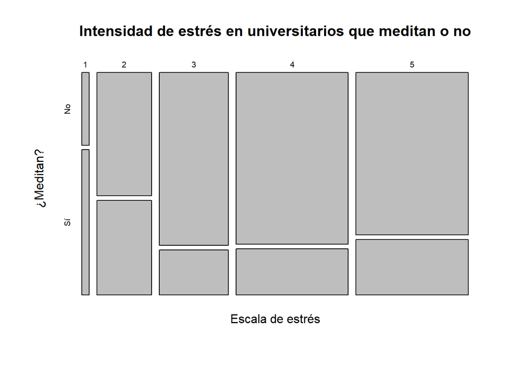

Análisis:

En el mosaico podemos observar que la intensidad más baja de estrés lo tienen, en mayor proporción, los universitarios que meditan. Por el otro lado, las intensidades mayores cuentan en su mayoría con universitarios que no meditan. Ello mostraría cierta relación entre la meditación y la intensidad de estrés que se siente.

### Rangos de medición de estrés (puntuación):

```
*   0-10: Por debajo del promedio
*   11-22: Promedio
*   23-29: Moderadamente por arriba del promedio
*   30 más: Mucho más arriba del promedio
```

## 6.2. Relación entre las horas semanales de ejercicio y la puntuación de estrés

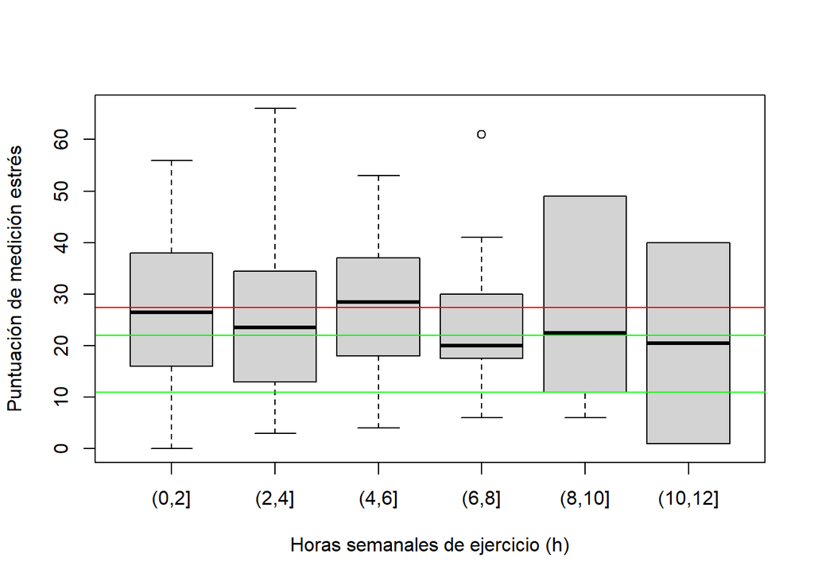

- **Media:** 27.36 (línea roja)
- Las líneas verdes representan tanto el mínimo como el máximo del rango promedio de la puntuación de estrés [11,22]

Análisis:

Podemos observar que las personas que realizan de 0 a 6 horas de ejercicios semanales poseen una mediana que está por encima del rango promedio, sin embargo, los universitarios que realizan de 6 a 12 horas, prácticamente se encuentran dentro del promedio, lo cual indicaría una mejor autorregulación de estrés:

## 6.3. Relación entre las horas diarias de ocio y puntuación de estrés

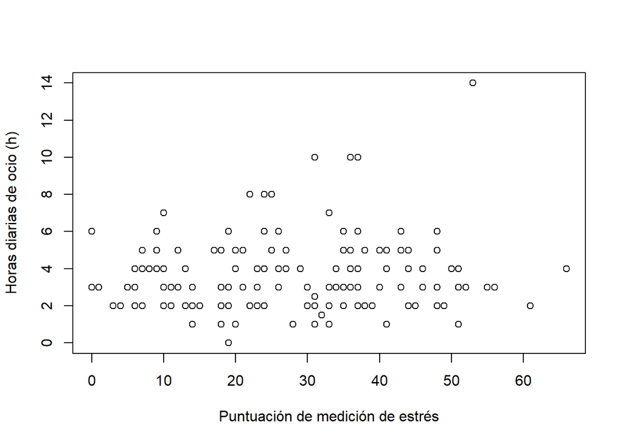

- **Covarianza:** 3.456365
- **Correlación:** 0.1130157

## 6.4. Relación entre las horas de sueño y puntuación de estrés

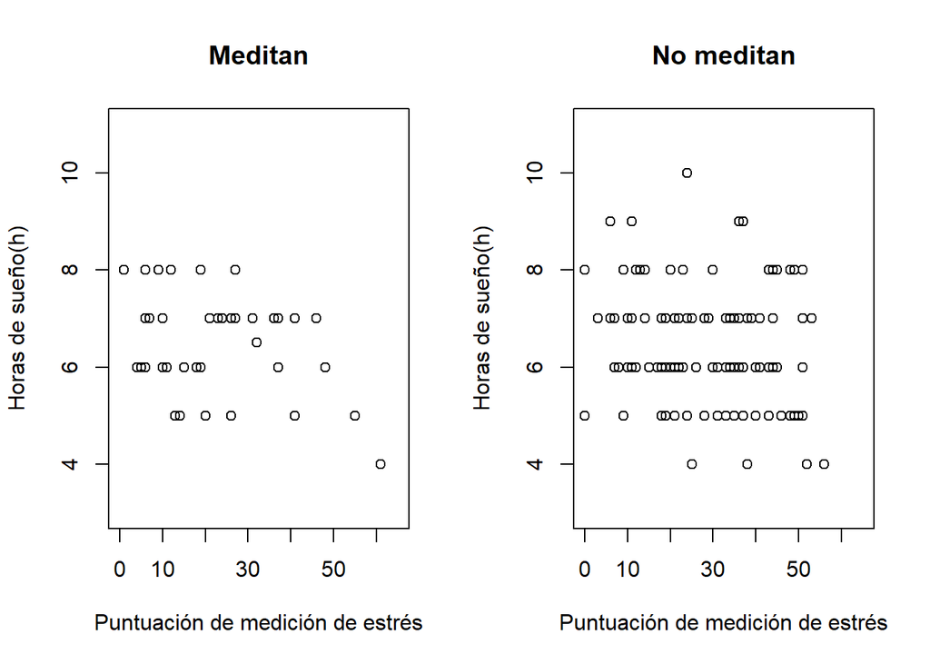

Corroborando:

*Meditan:*

- Covarianza:

```
## [1] -2.573228
```

- Correlación:

```
## [1] -0.1457689
```

*No meditan:*

- Covarianza:

```
## [1] -10.00481
```

- Correlación:

```
## [1] -0.4849586
```

Análisis:

Si bien es cierto que las gráficas tanto de los universitarios que no meditan con de los que meditan no tienen una tendencia lineal tan marcada, al comparar sus correlaciones y covarianzas entre sí, podemos observar que al menos la intensidad de la gráfica de las personas que no meditan es mayor que las que meditan. Esto quiere decir que mientras menos horas duerma una persona que no medita, tendrá una mayor puntuación de estrés, sin embargo, en la otra gráfica no variaría tanto, lo cual podría darnos a entender que el meditar mantendría la puntuación de estrés un poco más estable y no variaría tanto con respecto a las horas de sueño.

# 7. Modelos de variables aleatorias

## 7.1. Variable Continua - HorasSemanalesDeEjercicio

La variable “HoraSemanalesDeEjercicio” esta directamente relacionada con el problema identificado para el presente trabajo. Es por esto que, se realiza un estudio del comportamiento.

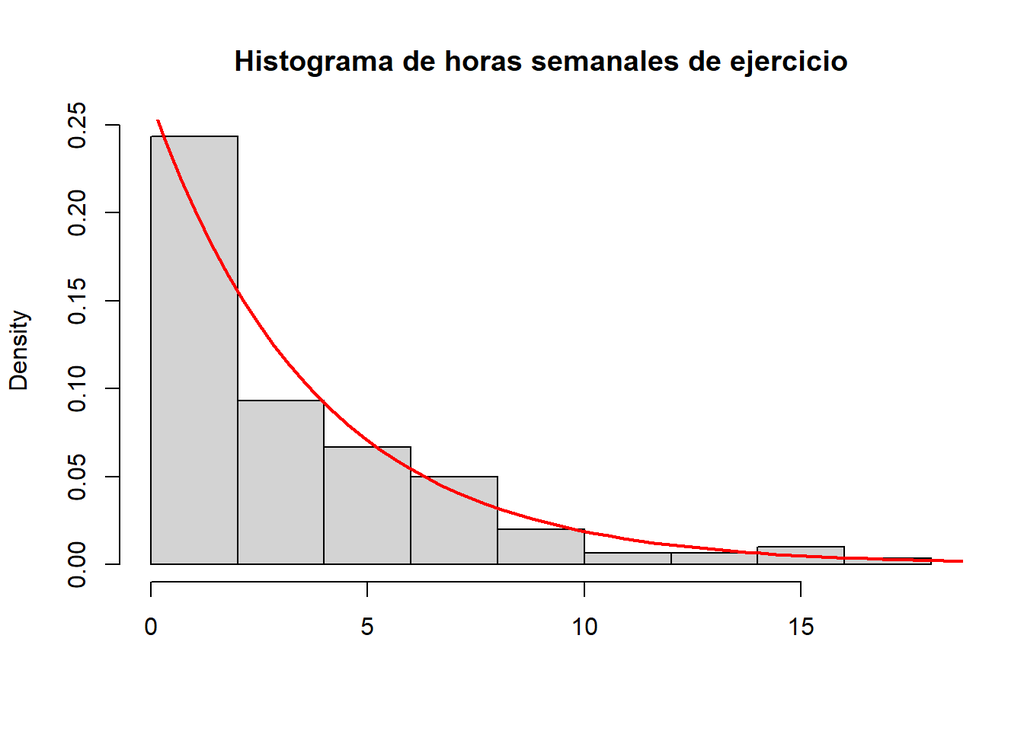

Como se puede observar en el histograma, la variable que representa las horas semanales de ejercicio se asemeja a una variable aleatoria continua en forma exponencial, por lo que se hallará el parámetro lambda a partir de la esperanza:

```
## [1] 0.2630425
```

## 7.2. Variable Continua - HorasDiariasDeSueno

La variable “HoraDiariasDeSueno” esta directamente relacionada con el problema identificado para el presente trabajo. Es por esto que, se realiza un estudio del comportamiento.

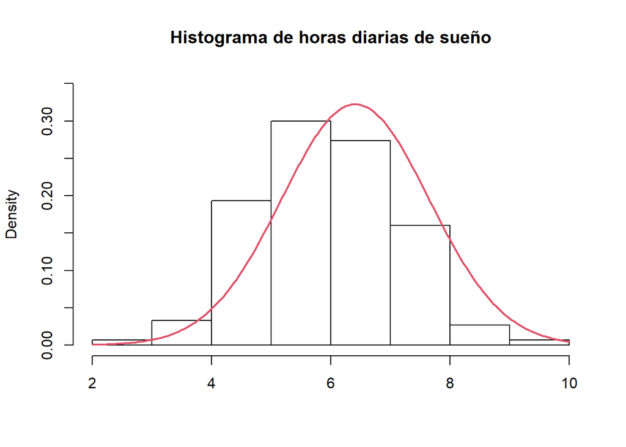

Se observa que la variable HorasDiariasDeSueno se asemeja a una distribución normal.

## 7.3. Variable Continua - HorasDiariasDeOcio

La variable “HorasDiariasDeOcio” esta directamente relacionada con el problema identificado para el presente. Es por esto que, se realiza un estudio del comportamiento.

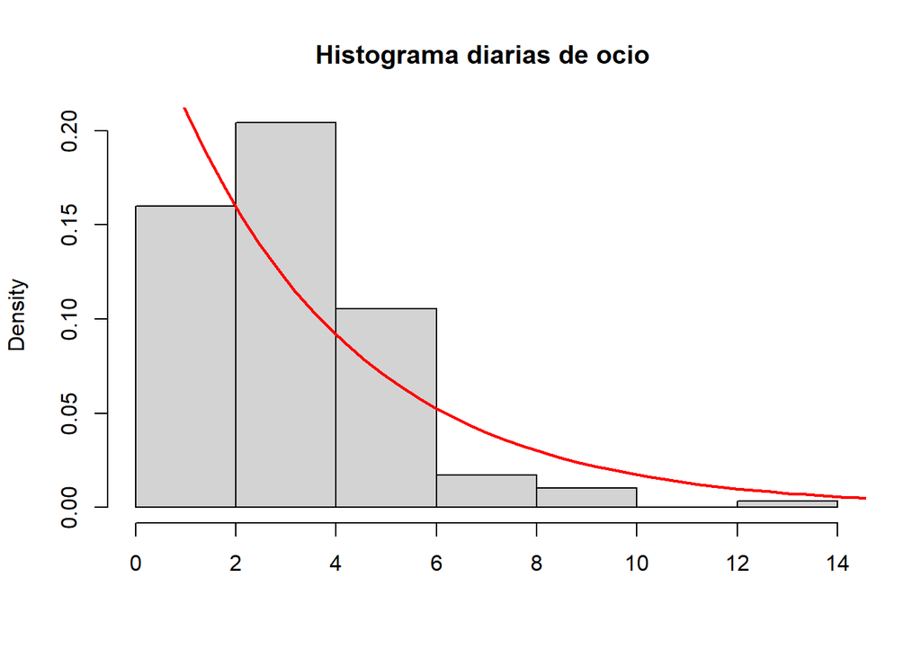

Además, la variable HorasDiariasDeOcio se asemeja a una distrbución exponencial.

## 7.4. Variable Discreta - ComidasDiarias

Se plantea esta relación entre las comidas diarias para evaluar el estilo de vida y así relacionarlo con el estrés. Con lo mencionado se plantea la siguiente pregunta: ¿A cuántos universitarios en promedio se debe de consultar sobre el numero de comidas diarias hasta obtener una primera persona que coma tres veces al día?

Éxito = una persona como tres veces al día.

$$Esperanza = \frac{1}{p}$$

Es así que obtenes como esperanza, con un valor de:

```
## [1] 2
```

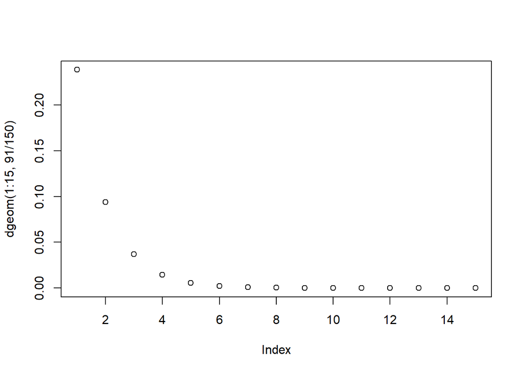

Como podemos observar, la gráfica muestra una variable aleatoria discreta Geométrica.

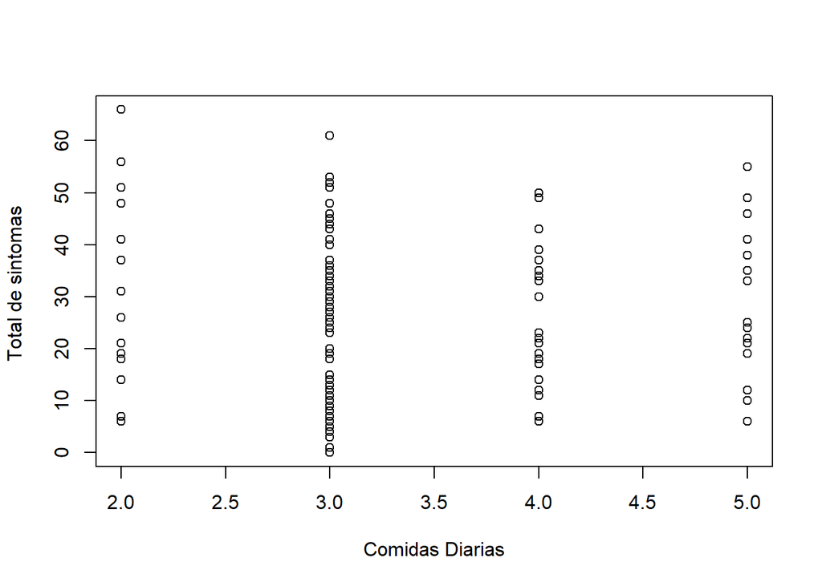

Como se observa en la gráfica la mayoría de individuos pertenecientes a nuestra muestra se concentra en las tres comidas diaria y respecto al total de síntomas hay una alta cantidad de individuos en el rango de 5 a 15 aproximadamente e igualmente en el rango 40 aproximadamente.

Y con respecto a la esperanza hallada para encontrar una persona que coma tres veces al día es de 2, probablemente para poder encontrar una persona que coma tres veces al día, se tiene consultar a dos personas en promedio, ya que como podemos observar la mayoría de individuos de nuestra muestra consumen tres comidas por día.

## 7.5. Variable Discreta - TotalSintomas

Se plantea esta relación mediante un rango acorde la frecuencia de síntomas del estrés (como lo son, fatiga, irritabilidad, cambios de ánimo, etc)

Probabilidades por cada puntuación de estrés:

```
##
##    0    1    3    4    5    6    7    8    9   10   11   12   13   14   15   17
## 0.01 0.01 0.01 0.01 0.01 0.03 0.03 0.01 0.02 0.03 0.03 0.02 0.01 0.03 0.01 0.01
##   18   19   20   21   22   23   24   25   26   27   28   29   30   31   32   33
## 0.04 0.05 0.03 0.03 0.01 0.02 0.03 0.01 0.03 0.01 0.01 0.01 0.01 0.03 0.01 0.03
##   34   35   36   37   38   39   40   41   43   44   45   46   48   49   50   51
## 0.01 0.03 0.03 0.04 0.01 0.01 0.03 0.03 0.03 0.02 0.01 0.01 0.03 0.02 0.01 0.03
##   52   53   55   56   61   66
## 0.01 0.01 0.01 0.01 0.01 0.01
```

Probabilidad mayor:

```
## [1] 0.05
```

Tal probabilidad mayor corresponde al valor 19 (dentro de la variable TotalSintomas), el cual nos indica que se encuentra dentro del promedio y, por ende, existe una buena autoregulación de estrés.

## 7.6. Variable Categórica - Meditación

### 7.6.1. Función Bernoulli

La variable meditación es una categórica nominal, trabajaremos con Bernoulli con fracaso y éxito, donde Éxito(sí medita) = 1 y Fracaso(no medita) = 0, además:
$$Rango(x)=\{0,1\},\;
P(x=1)=p,\; P(x=0)=1-p$$

Probabilidad de éxito:

```
## [1] 0.27
```

Probabilidad de fracaso:

```
## [1] 0.73
```

Con lo obtenido podemos concluir que la probabilidad de Éxito (que el individual sí medite) es del 27%.

### 7.6.2. Función binomial

Probabilidad de que al menos una persona medite en un grupo de 5 personas

```
## [1] 0.7926928
```

En este evento planteado podemos observar que en un grupo de 5 personas la probabilidad de éxito es 0.79, la cual es alta, ya que como pudimos ver en la gráfica que relaciona la puntuación de estrés, horas de sueño y meditación que indica que las personas que no meditan tienen una puntuación de estrés alta, entonces si de esas personas medita 1 por lo menos, al parecer tiene un mejor control de su estrés. La probabilidad de que por lo menos una persona que tenga un buen control de estrés es alto.

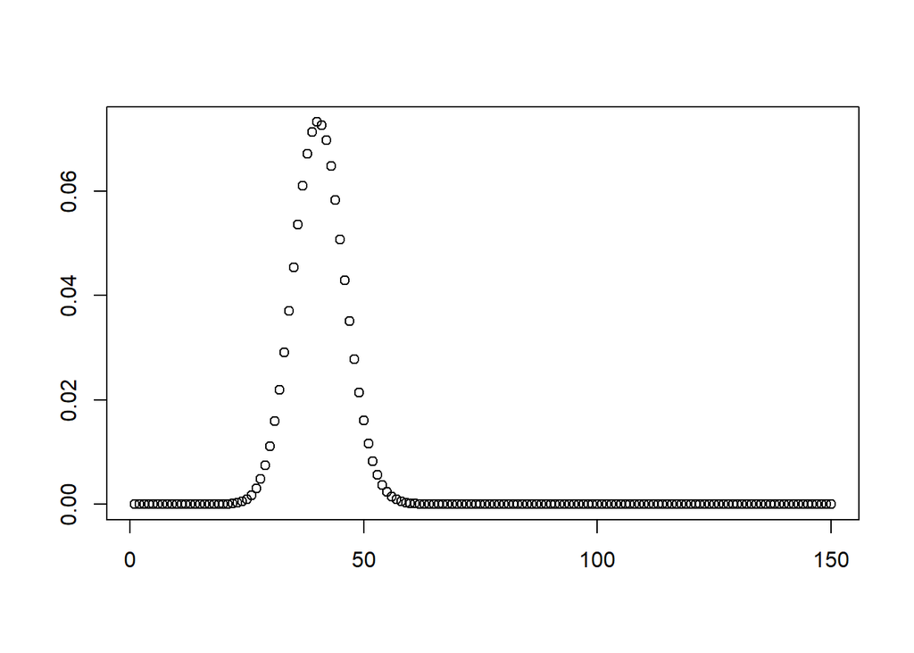

Como podemos observar en la gráfica al realizar 150 ensayos obtenemos una gráfica que se asemeja a la función Binomial con una probabilidad de éxito igual a 0.27

## 7.7. Probabilidad Condicional

La probabilidad condicional está presente para mostrar, en este caso, cómo afecta el estrés si “motivo 1” y/o “motivo 2”. De tal forma, se plantea la siguiente pregunta:

¿Cuál sería la probabilidad de que la escala de estrés de un universitario sea 5 dado que no hace deporte y come 5 veces al día?

```
##
##     2 3 4 5
##   2 0 0 3 0
##   3 2 1 4 8
##   4 0 0 1 0
##   5 0 0 0 1
```

En esta tabla tenemos en la parte superior la escala de estrés y por el lado izquierdo la cantidad de comidas diarias por día. Es por ello que luego se intersectó el evento principal con las restricciones establecidas y así poder obtener la probabilidad condicional.

```
## [1] 1
```

Esta respuesta si bien es cierto indica que siempre se cumpliría, en realidad hace referencia a que es muy probable que se cumpla bajo las restricciones dadas.

# 8. Análisis de fiabilidad

## 8.1. Variable: HorasDiariasdeSueno

Como observamos anteriormente, la variable númerica continua “HorasDiariasdeSueno” mantiene una distribución normal según el histograma mostrado. Además, la presente variable es de de vital importancia debido a su fuerte relación con el problema principal identificado a lo largo del trabajo. Por ello, se realiza un análisis de fiabilidad.

Tomando “n” lo suficientemente grande (n es igual al tamaño de la muestra) para poder corroborar si en verdad nuestro número de observaciones es el adecuado, obtendremos una aproximación según el modelo t(n-1), y como esperamos que n es lo suficientemente grande se puede aproximar a un modelo **Nor(u, sigma)**. Para ello, identificaremos nuestra desviación estandar y la media de la población, además se toma un nivel de confianza del 95% y un error de 0.2.

Entonces mediante la desviación estandar de la población aproximaremos el tamaño de la muestra mediante:

$$t_{crítico} = Qnorm(0.975) \\
t_{crítico} \leq \frac{0.2}{\frac{sd_{muestral}}{sqrt(n)}}$$

Despejando obtemos:

$$n \geq (\frac{(sd_{muestral} * t_{critico})}{0.2})^2$$

```
## [1] 148
```

Se contempla que para un error del 0.2 y un nivel de confianza del 95%, el tamaño de la muestra debe ser mayor o igual a 148, por ende nuestra muestra es de 150; por lo tanto, para dicho error y nivel de confianza sí se cumple.

Ahora, conocemos que la desviación estandar para este caso es:

```
## [1] 1.237108
```

Conocemos que:

- La variable X => HorasDiariasDeSueño ( X~Nor(6.41, sd_muestra) )
- La variable Xp es la media de X, por el teorema del limite central sigue una variable continua normal Norm(6.41, sd_muestra/sqrt(n)), donde n es el tamaño de la muestra (150)

Además:
$$X_p ~ Nor(6.41,\frac{sd_{muestra}}{sqrt(150)})$$

Estandarizando:
$$Z = (\frac{X_p - 6.41}{\frac{1.24}{sqrt(150)}})$$

$$Z \sim Nor(0,1)$$

```r
zcritico <- qnorm(0.975)

error_t = zcritico*(1.24/sqrt(150))
r(error_t)
```

```
## [1] 0.2
```

```r
xi <- 6.41-error_t
xf <- 6.41+error_t
r(xi)
```

```
## [1] 6.21
```

```r
r(xf)
```

```
## [1] 6.61
```

Podemos concluir que con un 95% de confianza la media cae en el intervalo de [6.21, 6.61], con un error estándar de 0.2.

## 8.2. Variable: HorasSemanalesDeEjercicio

Sobre la distribución exponencial observada anteriormente se podrá realizar un análisis de fiablidad.

```r
n<-((sd_muestra1*qnorm(0.85))/0.32)^2
round(n, 0)
```

```
## [1] 148
```

```r
zcritico <- qnorm(0.85)

error_t = zcritico*(sd_muestra1/sqrt(150))
r(error_t)
```

```
## [1] 0.32
```

```r
xi<-m_ejercicio - error_t
xf<-m_ejercicio + error_t
r(xi)
```

```
## [1] 3.48
```

```r
r(xf)
```

```
## [1] 4.12
```

## 8.3. Variable: HorasDiariasDeOcio

Tomando “n” lo suficientemente grande (n es igual al tamaño de la muestra) para poder corroborar si en verdad nuestro número de observaciones es el adecuado, obtendremos una aproximación según el modelo t(n-1), y como esperamos que n es lo suficientemente grande se puede aproximar a un modelo **Nor(u, sigma)**. Para ello, identificaremos nuestra desviación estandar y la media de la población, además se toma un nivel de confianza del 90% y un error de 0.27.

```r
n<-((sd_muestra2*qnorm(0.95))/0.27)^2
round(n, 0)
```

```
## [1] 155
```

```r
zcritico<-qnorm(0.95)

error_t=zcritico*(sd_muestra2/sqrt(150))
r(error_t)
```

```
## [1] 0.27
```

```r
xi<-m_ejercicio1 - error_t
xf<-m_ejercicio1 + error_t
r(xi)
```

```
## [1] 3.33
```

```r
r(xf)
```

```
## [1] 3.88
```

Como se observa, con un 90% de confianza la media cae en el intervalo de [3.33, 3.88], con un error estándar de 0.27.

# 9. Estadística inferencial

## 9.1. Variable: HorasDiariasDeSueno

```r
Estres_mayor_30 <- filter(DataBase1, DataBase1$TotalSintoma>=30)
Estres_menor_30 <- filter(DataBase1, DataBase1$TotalSintoma<30)
```

Media 1(puntuación>=30):

```
## [1] 6.183824
```

Con una varianza correspondiente a:

```
## [1] 1.790331
```

Media 2 (puntuación<30):

```r
mean(Estres_menor_30$HorasDiariasDeSueno)
```

```
## [1] 6.597561
```

Con una varianza correspondiente a:

```r
var(Estres_menor_30$HorasDiariasDeSueno)
```

```
## [1] 1.255796
```

$$\quad \mu_1- \mu_2=0\quad$$

$$\quad\mu_1- \mu_2\neq0\quad$$

```r
t.test(x=Estres_menor_30$HorasDiariasDeSueno,y=Estres_mayor_30$HorasDiariasDeSueno, alternative = "greater",conf.level = 0.95)
```

```
##
##  Welch Two Sample t-test
##
## data:  Estres_menor_30$HorasDiariasDeSueno and Estres_mayor_30$HorasDiariasDeSueno
## t = 2.0275, df = 130.96, p-value = 0.02232
## alternative hypothesis: true difference in means is greater than 0
## 95 percent confidence interval:
##  0.07568716        Inf
## sample estimates:
## mean of x mean of y
##  6.597561  6.183824
```

```r
alfa <- 0.05
qt(alfa,length(Estres_menor_30$HorasDiariasDeSueno)+length(Estres_mayor_30$HorasDiariasDeSueno)-2, lower.tail = 0)
```

```
## [1] 1.655215
```

**Hipotesis 2**

Media 1:

```r
mean(Estres_promedio$HorasSemanalesDeEjercicio)
```

```
## [1] 4.394531
```

$$\quad\mu\geq4.4\quad$$

- Ha: La media de las horas semanales de sueño de universitarios que no meditan con puntuación de estrés mayor o igual a 30 es mayor al de los universitarios con puntuación menor a 30.

$$\quad\mu<4.4\quad$$

```r
t.test(x=Estres_promedio$HorasDiariasDeSueno,y=Estres_promedio$HorasDiariasDeSueno, alternative = "greater",conf.level = 0.95)
```

```
##
##  Welch Two Sample t-test
##
## data:  Estres_promedio$HorasDiariasDeSueno and Estres_promedio$HorasDiariasDeSueno
## t = 0, df = 126, p-value = 0.5
## alternative hypothesis: true difference in means is greater than 0
## 95 percent confidence interval:
##  -0.3026095        Inf
## sample estimates:
## mean of x mean of y
##  6.609375  6.609375
```

```r
alfa <- 0.05
qt(alfa,length(Estres_promedio$HorasDiariasDeSueno)+length(Estres_promedio$HorasDiariasDeSueno)-2, lower.tail = 0)
```

```
## [1] 1.657037
```

### 9.2. Variable: HorasSemanalesDeEjercicio

Se plantea la siguiente pregunta siguiente pregunta: ¿Qué relación tiene las horas semanales de ejercicio con la puntuación total del estrés?

La media de las horas semanales del ejercicio es de 3.802 horas y la puntuación de estrés promedio es de 11 a 22, en este intervalo son los que parecen tener un mejor control del estrés, por lo cual plantearemos las siguientes hipótesis.

- Se tomará como hipótesis nula que los universitarios que realizan más de la media de cantidad de horas de ejercicio semanales presentan una bajo puntuación de estrés

$$\quad\mu\geq4.4\quad$$
- Se tomará como hipótesis alternativa que los universitarios que realizan menos de la media de cantidad de horas de ejercicios semanales presentan un alto puntuación de estrés.

Se realiza la prueba de hipótesis:

```
##
##  One Sample t-test
##
## data:  Estres_promedio$HorasSemanalesDeEjercicio
## t = -0.010554, df = 63, p-value = 0.5042
## alternative hypothesis: true mean is greater than 4.4
## 95 percent confidence interval:
##  3.529494      Inf
## sample estimates:
## mean of x
##  4.394531
```

Como p-value(0.5042) > significancia(0.05) **No se rechaza H0, ya que no se encontró suficiente evidencia.**

Como se observa en el gráfico, los datos muy dispersos.

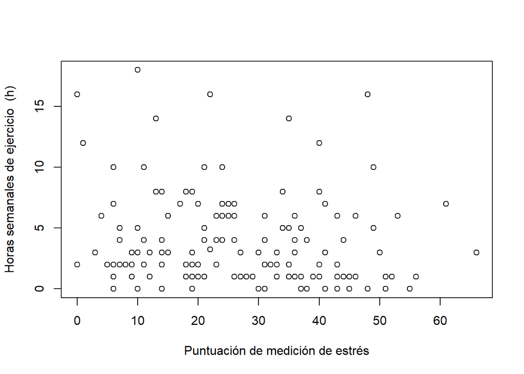

## 9.3. Variable: TotalSintomas

Tenemos que la proporción muestral de universitarios que tienen un puntaje de estrés mayor o igual que 30 es

```
## [1] 0.453
```

- H0:
  $$p\geq0.5$$
- H1:
  $$p<0.5\quad$$

Se realiza la prueba de hipótesis:

```r
n <- nrow(DataBase1)
prop.test(nrow(Estres_promedio),n,p=0.5,alternative="less",conf.level=0.95,correct=FALSE)
```

```
##
##  1-sample proportions test without continuity correction
##
## data:  nrow(Estres_promedio) out of n, null probability 0.5
## X-squared = 3.2267, df = 1, p-value = 0.03622
## alternative hypothesis: true p is less than 0.5
## 95 percent confidence interval:
##  0.0000000 0.4938124
## sample estimates:
##         p
## 0.4266667
```

# 10. Regresión

## 10.1. Variable: HorasDiariasDeSueno vs TotalSintoma

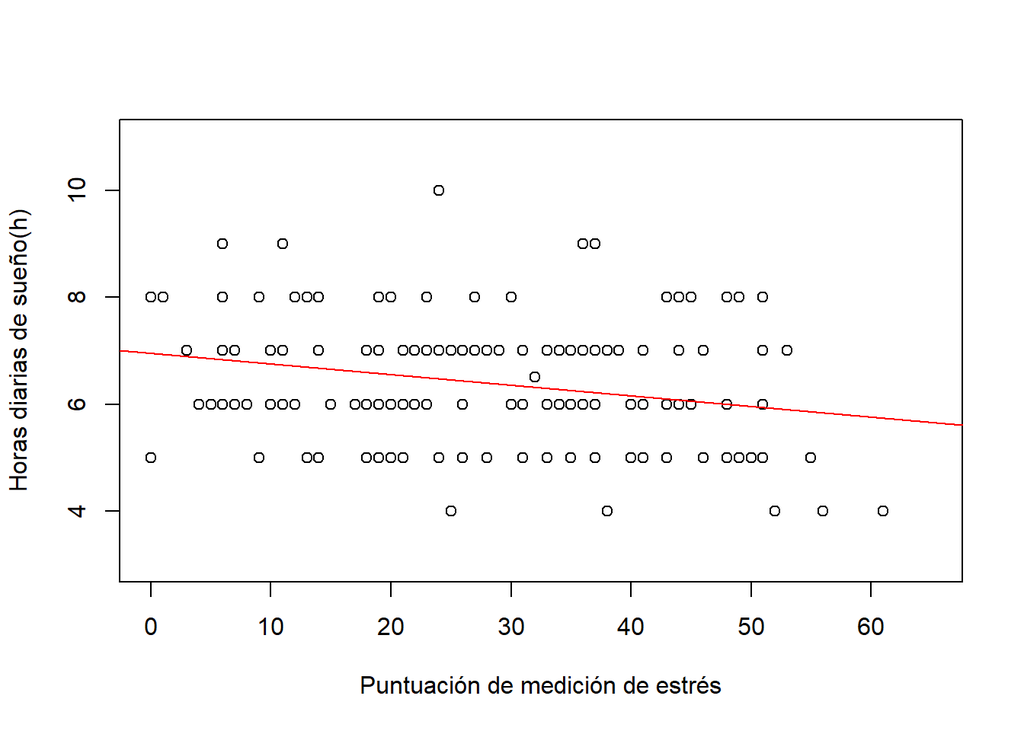

Resumen de la regresión:

```
##
## Call:
## lm(formula = DataBase1$HorasDiariasDeSueno ~ DataBase1$TotalSintoma)
##
## Residuals:
##     Min      1Q  Median      3Q     Max
## -3.6443 -0.8283 -0.1199  0.7761  3.5234
##
## Coefficients:
##                         Estimate Std. Error t value Pr(>|t|)
## (Intercept)             6.952176   0.205522  33.827  < 2e-16 ***
## DataBase1$TotalSintoma -0.019816   0.006595  -3.005  0.00312 **
## ---
## Signif. codes:  0 '***' 0.001 '**' 0.01 '*' 0.05 '.' 0.1 ' ' 1
##
## Residual standard error: 1.205 on 148 degrees of freedom
## Multiple R-squared:  0.0575, Adjusted R-squared:  0.05113
## F-statistic: 9.029 on 1 and 148 DF,  p-value: 0.003122
```

$$Y=b+a*X$$

**Hipótesis:**

$$\alpha=0.05$$

*Pendiente:*

- H0:
  $$a=0$$
- Ha:
  $$a\neq0$$

$$p-value=0.003$$

Se observa que el p-value (0.003) es menor a la significancia (0.05), es por ello que la hipótesis nula se rechaza.

*Intercepto:*

- H0:
  $$b =0$$
- Ha:
  $$b\neq0$$

**Donde**

$$p-value\approx0$$

Se observa que el p-value (aprox. 0) es menor a la significancia (0.05), es por ello que la hipótesis nula se rechaza.

Por último, cabe resaltar que el modelo sí es significativo, ya que su p-value(0.003) es menor que la significancia(0.05).

Correlación:

```
## [1] -0.2397851
```

Según la correlación podemos observar que como es cercana a 0, esta indica poco relación lineal entre las variables.

Gráficas de diagnóstico:

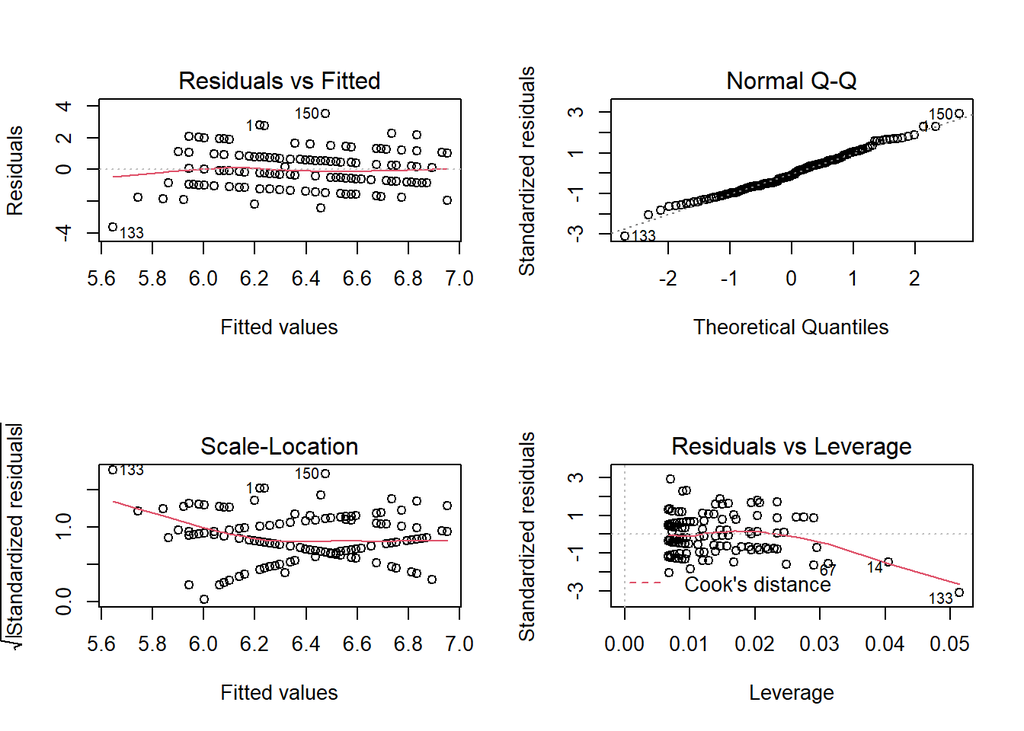

## 10.2. Variable: HorasSemanalesDeEjercicio vs TotalSintoma

[figure not shown]

Resumen de la regresión:

```
##
## Call:
## lm(formula = DataBase1$HorasSemanalesDeEjercicio ~ DataBase1$TotalSintoma)
##
## Residuals:
##    Min     1Q Median     3Q    Max
## -4.697 -2.636 -1.464  2.047 13.471
##
## Coefficients:
##                        Estimate Std. Error t value Pr(>|t|)
## (Intercept)             4.94851    0.63365   7.810 9.71e-13 ***
## DataBase1$TotalSintoma -0.04192    0.02033  -2.062    0.041 *
## ---
## Signif. codes:  0 '***' 0.001 '**' 0.01 '*' 0.05 '.' 0.1 ' ' 1
##
## Residual standard error: 3.715 on 148 degrees of freedom
## Multiple R-squared:  0.02791,    Adjusted R-squared:  0.02135
## F-statistic:  4.25 on 1 and 148 DF,  p-value: 0.041
```

$$Y=b+a*X$$

**Hipótesis:**

$$\alpha=0.05$$

*Pendiente:*

H0:
$$a=0$$
Ha:
$$a\neq0$$
$$p-value=0.041$$

Se observa que el p-value (0.041) es menor a la significancia (0.05), es por ello que la hipótesis nula se rechaza.

*Intercepto:*

H0:
$$b=0$$

Ha:
$$b\neq0$$

$$p-value\approx0$$

Se observa que el p-value (aprox. 0) es menor a la significancia (0.05), es por ello que la hipótesis nula se rechaza. Por último, cabe resaltar que el modelo sí es significativo, ya que su p-value(0.041) es menor que la significancia(0.05).

Correlación:

```
## [1] -0.1670725
```

Según la correlación podemos observar que como es cercana a 0, esta indica poco relación lineal entre las variables.

Gráficas de diagnóstico:

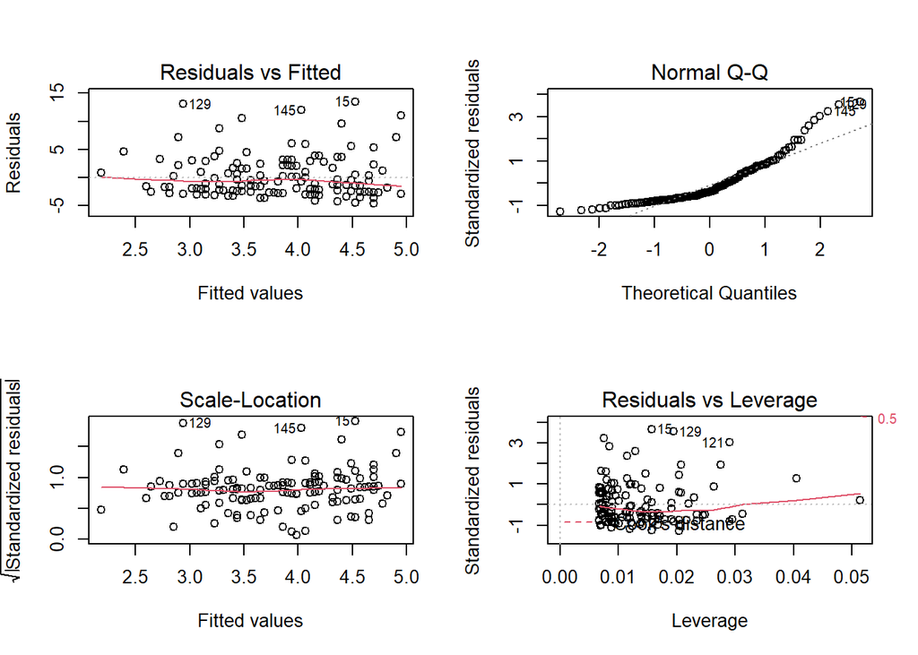

## 10.3. Variable: HorasDiariasDeOcio vs TotalSintoma

[figure not shown]

Resumen de la regresión:

```
##
## Call:
## lm(formula = DataBase1$HorasDiariasDeOcio ~ DataBase1$TotalSintoma)
##
## Residuals:
##     Min      1Q  Median      3Q     Max
## -3.4802 -1.3719 -0.4647  1.1637  9.9934
##
## Coefficients:
##                        Estimate Std. Error t value Pr(>|t|)
## (Intercept)             3.18610    0.34938   9.119 5.77e-16 ***
## DataBase1$TotalSintoma  0.01548    0.01130   1.370    0.173
## ---
## Signif. codes:  0 '***' 0.001 '**' 0.01 '*' 0.05 '.' 0.1 ' ' 1
##
## Residual standard error: 2.041 on 145 degrees of freedom
##   (3 observations deleted due to missingness)
## Multiple R-squared:  0.01277,    Adjusted R-squared:  0.005964
## F-statistic: 1.876 on 1 and 145 DF,  p-value: 0.1729
```

$$Y=b+a*X$$

- Y:HorasDiariasDeOcio
- X:TotalSintoma
- a:0.015
- b:3.186
- Hipótesis:

$$\alpha=0.05$$

*Pendiente:*

H0:
$$a=0$$
Ha:
$$a\neq0$$
$$p-value=0.173$$

Se observa que el p-value (0.173) es mayor a la significancia (0.05), es por ello que la hipótesis nula no se rechaza.

*Intercepto:*

H0:
$$b=0$$

Ha:
$$b\neq0$$

$$p-value\approx0$$

Se observa que el p-value (aprox. 0) es menor a la significancia (0.05), es por ello que la hipótesis nula se rechaza.

Correlación:

[output not shown]

Según la correlación podemos observar que como es cercana a 0, esta indica poco relación lineal entre las variables.

Gráficas de diagnóstico:

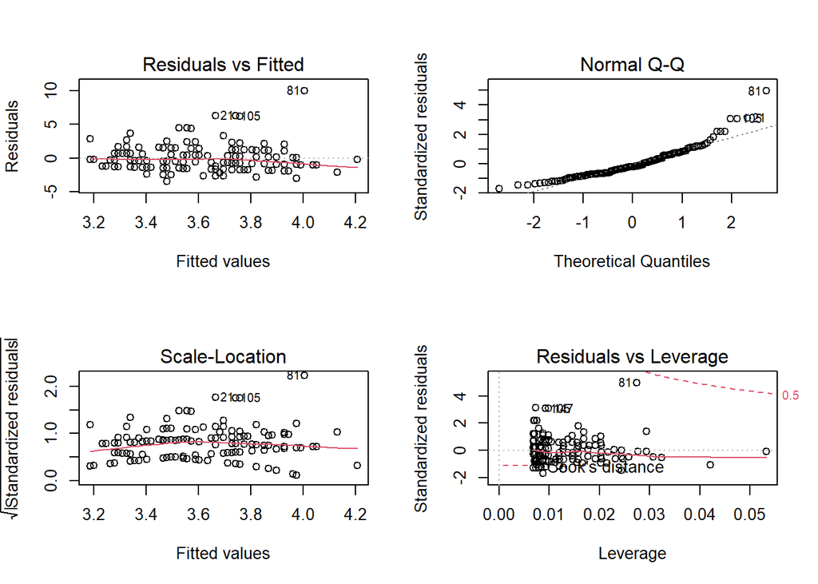

# 11. Conclusiones:

**General:**

- Se confirma que sí existe una relación entre el estilo de vida de las personas y su autorregulación del estrés, teniendo en cuenta las variables que consideramos más importantes (HorasSemanalesdeEjecicio, HorasDiariasDeSueno, Meditación)

# 12. Bibliografía:

- González Cabanach, R., Souto-Gestal, A., González-Doniz, L., & Franco Taboada, V. (2018). Perfiles de afrontamiento y estrés académico en estudiantes universitarios. Revista de Investigación Educativa, 36(2), 421–433. https://doi.org/10.6018/rie.36.2.290901
- Boullosa, G.I. (2013). Estrés académico y afrontamiento en un grupo de estudiantes de una universidad privada de lima (Tesis de licenciatura, Faculta de Letras y Ciencias Humanas, Pontificia Universidad Católica del Perú. Lima, Perú) . Recuperado de https://tesis.pucp.edu.pe/repositorio/handle/20.500.12404/488
- Estrés y ejercicio. Fundación Española del Corazón. Recuperado de https://fundaciondelcorazon.com/ejercicio/59-para-enfermos/1087-estres-y-ejercicio.html
- Los estudiantes que se duermen más tarde tienen mejor rendimiento académico. (2016, 18 mayo). Vicerrectorado Académico. Recuperado de https://vicerrectorado.pucp.edu.pe/academico/noticias/los-estudiantes-que-se-duermen-mas-tarde-tienen-mejor-rendimiento-academico/